# ST516 Homework 3

# An Allometric Model for Barnacles Revisited

#### 1. Estimate the model three ways: as a gamma GLM with the distribution/family specified as a gamma distribution, using a quasi-likelihood approach to specify the variance structure (using either quais or tweedie for the family argument), and by using iteratively weight least squares with nonlinear regression–similar to the last homework. Use the base-2 logarithm of rostro-carinal length rather than natural log. Report the parameter estimates, se’s, and CI’s.

```r
#subset barnacle data to remove values of 0 and an outlier
barnacle.subset <- barnacle[-c(2, 991, 1451),]
head(barnacle.subset)
```

```
##     DW   RC     F
## 1 0.14  9.5 barca
## 3 0.42 13.1 barca
## 4 0.01  3.7 barca
## 5 0.03  5.6 barca
## 6 1.56 18.6 barca
## 7 0.04  5.7 barca
```

```r
#gamma generalized linear model
m <- glm(DW ~ F * log2(RC), family = Gamma(link = log), data = barnacle.subset)
cbind(summary(m)$coefficients, confint(m))
```

```
##                Estimate Std. Error  t value  Pr(>|t|)    2.5 %   97.5 %
## (Intercept)    -8.07452   0.030794 -262.210 0.000e+00 -8.13389 -8.01487
## Flens          -0.14365   0.045212   -3.177 1.509e-03 -0.23098 -0.05631
## log2(RC)        1.97218   0.008679  227.225 0.000e+00  1.95539  1.98892
## Flens:log2(RC)  0.05263   0.012677    4.152 3.438e-05  0.02815  0.07711
```

```r
#quasi-likelihood model
m <- glm(DW ~  F * log2(RC), family = quasi(link = log, variance = "mu^2"), data = barnacle.subset)
cbind(summary(m)$coefficients, confint(m))
```

```
##                Estimate Std. Error  t value  Pr(>|t|)    2.5 %   97.5 %
## (Intercept)    -8.07452   0.030794 -262.210 0.000e+00 -8.13389 -8.01487
## Flens          -0.14365   0.045212   -3.177 1.509e-03 -0.23098 -0.05631
## log2(RC)        1.97218   0.008679  227.225 0.000e+00  1.95539  1.98892
## Flens:log2(RC)  0.05263   0.012677    4.152 3.438e-05  0.02815  0.07711
```

```r
#iteratively weight least squares model
m2 <- nls(DW ~ exp(t0 + t1 * (F == "lens") +
  (t2 + t3 * (F == "lens")) * log2(RC)), data = barnacle.subset,
  start = c(t0 = -8.07, t1 = 0.14, t2 = 1.97, t3 = 0.05))

for (i in 1:10) {
  barnacle.subset$w <- 1/predict(m2)^2
  m2 <- nls(DW ~ exp(t0 + t1 * (F == "lens") + (t2 + t3 * (F == "lens")) * log2(RC)),
           data = barnacle.subset, start = coef(m2), weights = w)
}

cbind(summary(m2)$coefficients, confint(m2))
```

```
##    Estimate Std. Error  t value  Pr(>|t|)     2.5%    97.5%
## t0 -8.07452   0.030794 -262.210 0.000e+00 -8.13621 -8.01365
## t1 -0.14366   0.045212   -3.177 1.509e-03 -0.23370 -0.05368
## t2  1.97218   0.008679  227.225 0.000e+00  1.95497  1.98953
## t3  0.05263   0.012677    4.152 3.437e-05  0.02739  0.07789
```

#### 2. Write out the regression model implied by the results of summary from glm in its mathematical form to show how the E(Yi) is related to the explanatory variables. Be sure to define each explanatory variable to show that you know how it is computed based on the raw data. Also write the model case-wise for each location.

E(Y<sub>i</sub>) = exp(B<sub>0</sub> + B<sub>1</sub>X<sub>i1</sub> + B<sub>2</sub>X<sub>i2</sub> + B<sub>3</sub>X<sub>i3</sub>)

x<sub>i1</sub> = 1 if ‘F’ is ‘lens’, and 0 if ‘F’ is ‘barca’

x<sub>i2</sub> = log<sub>2</sub>(RC)

x<sub>i3</sub> = x<sub>i1</sub> * x<sub>i2</sub>

Casewise:

if ‘F’ == ‘barca’: E(Y<sub>i</sub>) = exp(B<sub>0</sub> + B<sub>2</sub>*log<sub>2</sub>(RC))

if ‘F’ == ‘lens’ : E(Y<sub>i</sub>) = exp(B<sub>0</sub> + B<sub>1</sub> + (B<sub>2</sub> + B<sub>3</sub>) * log<sub>2</sub>(RC))

#### 3. Use contrast to estimate the multiplicative effect of rostro-carinal length for each location. Use base-2 log in model. Summarize the effect.

Summary: For each doubling of RC length, the dry weight of barnacles: at Punta de Barca increases by a factor of 7.18 and at Punta de Lens by a factor of 7.58.

```r
contrast(m,
         a = list(RC = 20, F = c('barca', 'lens')),
         b = list(RC = 10, F = c('barca', 'lens')),
         cnames = c('barca', 'lens'), tf = exp)
```

```
##       estimate       se lower upper tvalue   df pvalue
## barca    7.186 0.008679 7.065 7.310  227.2 1993      0
## lens     7.575 0.009240 7.439 7.713  219.1 1993      0
```

#### 4. Produce a studentized residual plot to check to see if the specified variance structure was appropriate. Comment on whether you believe the variance structure was modeled correctly and why.

Comment: The variance structure was not modeled correctly because the studentized residuals show decreasing variance.

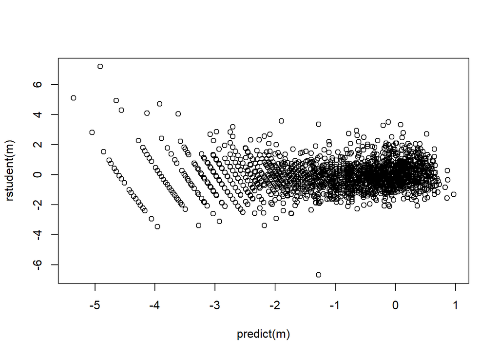

```r
plot(predict(m), rstudent(m))
```

#### 5. Conduct a significance test to determine if the difference between the multiplicative effect in the different locations is statistically significant.

```r
m <- glm(DW ~ F * log2(RC), family = Gamma(link = log), data = barnacle.subset)
m.null <- glm(DW ~ F + log2(RC), family = Gamma(link = log), data = barnacle.subset)
anova(m.null, m, test = "LRT")
```

```
## Analysis of Deviance Table
##
## Model 1: DW ~ F + log2(RC)
## Model 2: DW ~ F * log2(RC)
##   Resid. Df Resid. Dev Df Deviance Pr(>Chi)
## 1      1994       58.4
## 2      1993       57.9  1    0.552  2.5e-05 ***
## ---
## Signif. codes:  0 '***' 0.001 '**' 0.01 '*' 0.05 '.' 0.1 ' ' 1
```

# Moth Habitat Study

#### 1. Estimate the model and report output from summary. Try obtaining profile likelihood ratio CI’s (you will get an error but still report). Obtain Wald CI’s for the model parameters using coeftest or lincon. Change the habitat reference level to “Disturbed” using relevel. Report output from summary, try obtaining both types of CI’s again. Estimate a model without an interaction and report the results from summary and try to obtain both types of CI’s. Discuss what you observed when comparing results from all three models/parameterizations. What did you notice that was unusual?

Discussion: When the reference level for habitat was changed to “Disturbed”, the parameter estimates for the “Bank” level were much greater than the other habitat levels, and the standard errors for the “Bank” level were many orders of magnitude greater than the other habitat levels. Something is going wrong with the model in relation to the Bank habitat level. When the interaction between habitat and moth type is removed from the model, there is nothing odd about the ‘Bank’ level parameter estimates and standard errors.

```r
#put data into long form
moths.long <- gather(moths, A, P, key = 'type', value = 'count')

#model rate of count/m with effect of habitat, type, and interaction
m <- glm(count ~ offset(log(meters)) + type * habitat,
         family = poisson, data = moths.long)
summary(m)$coefficients
```

```
##                        Estimate Std. Error  z value Pr(>|z|)
## (Intercept)              -17.35      773.8 -0.02242   0.9821
## typeP                     15.69      773.8  0.02028   0.9838
## habitatDisturbed          15.53      773.8  0.02008   0.9840
## habitatLowerside          15.81      773.8  0.02043   0.9837
## habitatNEsoak             14.45      773.8  0.01867   0.9851
## habitatNWsoak             17.44      773.8  0.02253   0.9820
## habitatSEsoak             15.70      773.8  0.02028   0.9838
## habitatSWsoak             15.59      773.8  0.02015   0.9839
## habitatUpperside          13.82      773.8  0.01786   0.9857
## typeP:habitatDisturbed   -14.27      773.8 -0.01844   0.9853
## typeP:habitatLowerside   -16.57      773.8 -0.02141   0.9829
## typeP:habitatNEsoak      -15.69      773.8 -0.02028   0.9838
## typeP:habitatNWsoak      -17.01      773.8 -0.02198   0.9825
## typeP:habitatSEsoak      -17.51      773.8 -0.02263   0.9819
## typeP:habitatSWsoak      -14.81      773.8 -0.01914   0.9847
## typeP:habitatUpperside   -16.94      773.8 -0.02189   0.9825
```

```r
#try obtaining profile likelihood ratio CI
confint(m)
```

```
## Error in glm.fit(x = Xi, y = Y, weights = W, etastart = LP, offset = o, : NA/NaN/Inf in 'x'
```

```r
#Obtain Wald CI for model parameters with coeftest or lincon
lincon(m)
```

```
##                        estimate    se lower upper   tvalue  df pvalue
## (Intercept)              -17.35 773.8 -1534  1499 -0.02242 Inf 0.9821
## typeP                     15.69 773.8 -1501  1532  0.02028 Inf 0.9838
## habitatDisturbed          15.53 773.8 -1501  1532  0.02008 Inf 0.9840
## habitatLowerside          15.81 773.8 -1501  1532  0.02043 Inf 0.9837
## habitatNEsoak             14.45 773.8 -1502  1531  0.01867 Inf 0.9851
## habitatNWsoak             17.44 773.8 -1499  1534  0.02253 Inf 0.9820
## habitatSEsoak             15.70 773.8 -1501  1532  0.02028 Inf 0.9838
## habitatSWsoak             15.59 773.8 -1501  1532  0.02015 Inf 0.9839
## habitatUpperside          13.82 773.8 -1503  1530  0.01786 Inf 0.9857
## typeP:habitatDisturbed   -14.27 773.8 -1531  1502 -0.01844 Inf 0.9853
## typeP:habitatLowerside   -16.57 773.8 -1533  1500 -0.02141 Inf 0.9829
## typeP:habitatNEsoak      -15.69 773.8 -1532  1501 -0.02028 Inf 0.9838
## typeP:habitatNWsoak      -17.01 773.8 -1534  1500 -0.02198 Inf 0.9825
## typeP:habitatSEsoak      -17.51 773.8 -1534  1499 -0.02263 Inf 0.9819
## typeP:habitatSWsoak      -14.81 773.8 -1531  1502 -0.01914 Inf 0.9847
## typeP:habitatUpperside   -16.94 773.8 -1534  1500 -0.02189 Inf 0.9825
```

```r
#change reference level to "Disturbed" using relevel. Report output from summary, try obtaining both types of CI's again.
moths.long$habitat <- relevel(moths.long$habitat, ref = "Disturbed")
m <- glm(count ~ offset(log(meters)) + type * habitat,
         family = poisson, data = moths.long)
summary(m)$coefficients
```

```
##                         Estimate Std. Error  z value  Pr(>|z|)
## (Intercept)             -1.81238     0.3536 -5.12618 2.957e-07
## typeP                    1.41707     0.3941  3.59584 3.233e-04
## habitatBank            -15.53473   773.7839 -0.02008 9.840e-01
## habitatLowerside         0.27368     0.3865  0.70807 4.789e-01
## habitatNEsoak           -1.08590     0.4432 -2.45012 1.428e-02
## habitatNWsoak            1.90067     0.3729  5.09645 3.461e-07
## habitatSEsoak            0.16061     0.3899  0.41191 6.804e-01
## habitatSWsoak            0.05452     0.4183  0.13033 8.963e-01
## habitatUpperside        -1.71398     0.4009 -4.27542 1.908e-05
## typeP:habitatBank       14.27181   773.7841  0.01844 9.853e-01
## typeP:habitatLowerside  -2.29742     0.4884 -4.70416 2.549e-06
## typeP:habitatNEsoak     -1.41707     0.5460 -2.59517 9.455e-03
## typeP:habitatNWsoak     -2.73531     0.4712 -5.80512 6.432e-09
## typeP:habitatSEsoak     -3.23622     0.5908 -5.47807 4.300e-08
## typeP:habitatSWsoak     -0.54160     0.4755 -1.13891 2.547e-01
## typeP:habitatUpperside  -2.66983     0.5622 -4.74928 2.041e-06
```

```r
lincon(m)
```

```
##                         estimate       se      lower     upper   tvalue
## (Intercept)             -1.81238   0.3536    -2.5053   -1.1194 -5.12618
## typeP                    1.41707   0.3941     0.6447    2.1895  3.59584
## habitatBank            -15.53473 773.7839 -1532.1233 1501.0539 -0.02008
## habitatLowerside         0.27368   0.3865    -0.4839    1.0312  0.70807
## habitatNEsoak           -1.08590   0.4432    -1.9546   -0.2172 -2.45012
## habitatNWsoak            1.90067   0.3729     1.1697    2.6316  5.09645
## habitatSEsoak            0.16061   0.3899    -0.6036    0.9248  0.41191
## habitatSWsoak            0.05452   0.4183    -0.7654    0.8744  0.13033
## habitatUpperside        -1.71398   0.4009    -2.4997   -0.9282 -4.27542
## typeP:habitatBank       14.27181 773.7841 -1502.3171 1530.8608  0.01844
## typeP:habitatLowerside  -2.29742   0.4884    -3.2546   -1.3402 -4.70416
## typeP:habitatNEsoak     -1.41707   0.5460    -2.4873   -0.3468 -2.59517
## typeP:habitatNWsoak     -2.73531   0.4712    -3.6588   -1.8118 -5.80512
## typeP:habitatSEsoak     -3.23622   0.5908    -4.3941   -2.0784 -5.47807
## typeP:habitatSWsoak     -0.54160   0.4755    -1.4736    0.3904 -1.13891
## typeP:habitatUpperside  -2.66983   0.5622    -3.7716   -1.5680 -4.74928
##                         df    pvalue
## (Intercept)            Inf 2.957e-07
## typeP                  Inf 3.233e-04
## habitatBank            Inf 9.840e-01
## habitatLowerside       Inf 4.789e-01
## habitatNEsoak          Inf 1.428e-02
## habitatNWsoak          Inf 3.461e-07
## habitatSEsoak          Inf 6.804e-01
## habitatSWsoak          Inf 8.963e-01
## habitatUpperside       Inf 1.908e-05
## typeP:habitatBank      Inf 9.853e-01
## typeP:habitatLowerside Inf 2.549e-06
## typeP:habitatNEsoak    Inf 9.455e-03
## typeP:habitatNWsoak    Inf 6.432e-09
## typeP:habitatSEsoak    Inf 4.300e-08
## typeP:habitatSWsoak    Inf 2.547e-01
## typeP:habitatUpperside Inf 2.041e-06
```

```r
confint(m)
```

```
## Error in glm.fit(x = Xi, y = Y, weights = W, etastart = LP, offset = o, : NA/NaN/Inf in 'x'
```

```r
#Estimate model without an interaction
m <- glm(count ~ offset(log(meters)) + type + habitat,
         family = poisson, data = moths.long)
summary(m)$coefficients
```

```
##                  Estimate Std. Error z value  Pr(>|z|)
## (Intercept)       -0.6973     0.1620  -4.304 1.674e-05
## typeP             -0.3851     0.1062  -3.627 2.872e-04
## habitatBank       -1.4800     0.5238  -2.825 4.723e-03
## habitatLowerside  -1.0136     0.2040  -4.968 6.778e-07
## habitatNEsoak     -2.0269     0.2452  -8.268 1.368e-16
## habitatNWsoak      0.5037     0.1884   2.673 7.514e-03
## habitatSEsoak     -1.3232     0.2183  -6.062 1.343e-09
## habitatSWsoak     -0.3558     0.1977  -1.800 7.192e-02
## habitatUpperside  -3.0968     0.2284 -13.558 7.059e-42
```

```r
lincon(m)
```

```
##                  estimate     se   lower   upper  tvalue  df    pvalue
## (Intercept)       -0.6973 0.1620 -1.0147 -0.3798  -4.304 Inf 1.674e-05
## typeP             -0.3851 0.1062 -0.5933 -0.1770  -3.627 Inf 2.872e-04
## habitatBank       -1.4800 0.5238 -2.5067 -0.4533  -2.825 Inf 4.723e-03
## habitatLowerside  -1.0136 0.2040 -1.4135 -0.6137  -4.968 Inf 6.778e-07
## habitatNEsoak     -2.0269 0.2452 -2.5074 -1.5464  -8.268 Inf 1.368e-16
## habitatNWsoak      0.5037 0.1884  0.1344  0.8730   2.673 Inf 7.514e-03
## habitatSEsoak     -1.3232 0.2183 -1.7511 -0.8954  -6.062 Inf 1.343e-09
## habitatSWsoak     -0.3558 0.1977 -0.7434  0.0317  -1.800 Inf 7.192e-02
## habitatUpperside  -3.0968 0.2284 -3.5445 -2.6491 -13.558 Inf 7.059e-42
```

```r
confint(m)
```

```
##                    2.5 %   97.5 %
## (Intercept)      -1.0304 -0.39389
## typeP            -0.5948 -0.17817
## habitatBank      -2.6826 -0.57349
## habitatLowerside -1.4102 -0.60772
## habitatNEsoak    -2.5170 -1.55132
## habitatNWsoak     0.1418  0.88261
## habitatSEsoak    -1.7520 -0.89305
## habitatSWsoak    -0.7384  0.03918
## habitatUpperside -3.5485 -2.64944
```

#### 2. Estimate the model with an interaction, but omitting data from transects from the “Bank” habitat type. Report parameter estimates, se’s, and profile likelihood and Wald CI’s.

```r
#omit data from transects from the Bank habitat type
moths.long.subset <- subset(moths.long, habitat != "Bank")

#estimate model
m <- glm(count ~ offset(log(meters)) + type * habitat,
         family = poisson, data = moths.long.subset)
summary(m)$coefficients
```

```
##                        Estimate Std. Error z value  Pr(>|z|)
## (Intercept)            -1.81238     0.3536 -5.1262 2.957e-07
## typeP                   1.41707     0.3941  3.5958 3.233e-04
## habitatLowerside        0.27368     0.3865  0.7081 4.789e-01
## habitatNEsoak          -1.08590     0.4432 -2.4501 1.428e-02
## habitatNWsoak           1.90067     0.3729  5.0964 3.461e-07
## habitatSEsoak           0.16061     0.3899  0.4119 6.804e-01
## habitatSWsoak           0.05452     0.4183  0.1303 8.963e-01
## habitatUpperside       -1.71398     0.4009 -4.2754 1.908e-05
## typeP:habitatLowerside -2.29742     0.4884 -4.7042 2.549e-06
## typeP:habitatNEsoak    -1.41707     0.5460 -2.5952 9.455e-03
## typeP:habitatNWsoak    -2.73531     0.4712 -5.8051 6.432e-09
## typeP:habitatSEsoak    -3.23622     0.5908 -5.4781 4.300e-08
## typeP:habitatSWsoak    -0.54160     0.4755 -1.1389 2.547e-01
## typeP:habitatUpperside -2.66983     0.5622 -4.7493 2.041e-06
```

```r
lincon(m)
```

```
##                        estimate     se   lower   upper  tvalue  df
## (Intercept)            -1.81238 0.3536 -2.5053 -1.1194 -5.1262 Inf
## typeP                   1.41707 0.3941  0.6447  2.1895  3.5958 Inf
## habitatLowerside        0.27368 0.3865 -0.4839  1.0312  0.7081 Inf
## habitatNEsoak          -1.08590 0.4432 -1.9546 -0.2172 -2.4501 Inf
## habitatNWsoak           1.90067 0.3729  1.1697  2.6316  5.0964 Inf
## habitatSEsoak           0.16061 0.3899 -0.6036  0.9248  0.4119 Inf
## habitatSWsoak           0.05452 0.4183 -0.7654  0.8744  0.1303 Inf
## habitatUpperside       -1.71398 0.4009 -2.4997 -0.9282 -4.2754 Inf
## typeP:habitatLowerside -2.29742 0.4884 -3.2546 -1.3402 -4.7042 Inf
## typeP:habitatNEsoak    -1.41707 0.5460 -2.4873 -0.3468 -2.5952 Inf
## typeP:habitatNWsoak    -2.73531 0.4712 -3.6588 -1.8118 -5.8051 Inf
## typeP:habitatSEsoak    -3.23622 0.5908 -4.3941 -2.0784 -5.4781 Inf
## typeP:habitatSWsoak    -0.54160 0.4755 -1.4736  0.3904 -1.1389 Inf
## typeP:habitatUpperside -2.66983 0.5622 -3.7716 -1.5680 -4.7493 Inf
##                           pvalue
## (Intercept)            2.957e-07
## typeP                  3.233e-04
## habitatLowerside       4.789e-01
## habitatNEsoak          1.428e-02
## habitatNWsoak          3.461e-07
## habitatSEsoak          6.804e-01
## habitatSWsoak          8.963e-01
## habitatUpperside       1.908e-05
## typeP:habitatLowerside 2.549e-06
## typeP:habitatNEsoak    9.455e-03
## typeP:habitatNWsoak    6.432e-09
## typeP:habitatSEsoak    4.300e-08
## typeP:habitatSWsoak    2.547e-01
## typeP:habitatUpperside 2.041e-06
```

```r
confint(m)
```

```
##                          2.5 %  97.5 %
## (Intercept)            -2.5955 -1.1911
## typeP                   0.6954  2.2619
## habitatLowerside       -0.4290  1.1071
## habitatNEsoak          -1.9337 -0.1682
## habitatNWsoak           1.2318  2.7135
## habitatSEsoak          -0.5506  0.9991
## habitatSWsoak          -0.7288  0.9356
## habitatUpperside       -2.4529 -0.8589
## typeP:habitatLowerside -3.3099 -1.3808
## typeP:habitatNEsoak    -2.5280 -0.3702
## typeP:habitatNWsoak    -3.7170 -1.8549
## typeP:habitatSEsoak    -4.4818 -2.1457
## typeP:habitatSWsoak    -1.5201  0.3633
## typeP:habitatUpperside -3.8388 -1.6195
```

#### 3. Use contrast or glmint to report point estimates and CI’s for the expected number of moths per meter for each of the 14 combinations of habitat and moth type.

```r
#moth A point estimates
contrast(m,
         a = list(type = 'A',
                  habitat = c('Disturbed', 'Lowerside', 'NEsoak', 'NWsoak', 'SEsoak', 'SWsoak', 'Upperside'),
                  meters = 1),
         tf = exp,
         cnames = paste("Moth A at", c('Disturbed', 'Lowerside', 'NEsoak', 'NWsoak', 'SEsoak', 'SWsoak', 'Upperside')))
```

```
##                     estimate     se   lower   upper  tvalue  df    pvalue
## Moth A at Disturbed  0.16327 0.3536 0.08165 0.32647  -5.126 Inf 2.957e-07
## Moth A at Lowerside  0.21466 0.1562 0.15806 0.29153  -9.853 Inf 6.686e-23
## Moth A at NEsoak     0.05512 0.2673 0.03264 0.09307 -10.844 Inf 2.121e-27
## Moth A at NWsoak     1.09231 0.1187 0.86562 1.37836   0.744 Inf 4.569e-01
## Moth A at SEsoak     0.19171 0.1644 0.13890 0.26459 -10.047 Inf 9.438e-24
## Moth A at SWsoak     0.17241 0.2236 0.11123 0.26724  -7.861 Inf 3.799e-15
## Moth A at Upperside  0.02941 0.1890 0.02031 0.04260 -18.660 Inf 1.052e-77
```

```r
#moth b point estimates
contrast(m,
         a = list(type = 'P',
                  habitat = c('Disturbed', 'Lowerside', 'NEsoak', 'NWsoak', 'SEsoak', 'SWsoak', 'Upperside'),
                  meters = 1),
         tf = exp,
         cnames = paste("Moth P at", c('Disturbed', 'Lowerside', 'NEsoak', 'NWsoak', 'SEsoak', 'SWsoak', 'Upperside')))
```

```
##                     estimate     se    lower   upper  tvalue  df    pvalue
## Moth P at Disturbed 0.673469 0.1741 0.478787 0.94731  -2.271 Inf 2.315e-02
## Moth P at Lowerside 0.089005 0.2425 0.055331 0.14317  -9.974 Inf 1.980e-23
## Moth P at NEsoak    0.055118 0.2673 0.032644 0.09307 -10.844 Inf 2.121e-27
## Moth P at NWsoak    0.292308 0.2294 0.186449 0.45827  -5.361 Inf 8.266e-08
## Moth P at SEsoak    0.031088 0.4082 0.013967 0.06920  -8.502 Inf 1.863e-17
## Moth P at SWsoak    0.413793 0.1443 0.311834 0.54909  -6.113 Inf 9.755e-10
## Moth P at Upperside 0.008403 0.3536 0.004203 0.01680 -13.517 Inf 1.235e-41
```

#### 4. Use contrast to estimate the effect of moth type as a multiplicative effect for the Disturbed, Lowerside, and Upperside habitats. Summarize the effect.

Summary: The expected number of P moths per meter in the Disturbed habitat is 4.1 times greater than the expected number of A moths per meter.

```r
contrast(m,
         a = list(type = 'P',
                  habitat = c('Disturbed', 'Lowerside', 'Upperside'),
                  meters = 1),
         b = list(type = 'A',
                  habitat = c('Disturbed', 'Lowerside', 'Upperside'),
                  meters = 1),
         tf = exp,
         cnames = paste("P vs A at", c('Disturbed', 'Lowerside', 'Upperside')))
```

```
##                     estimate     se  lower  upper tvalue  df    pvalue
## P vs A at Disturbed   4.1250 0.3941 1.9054 8.9304  3.596 Inf 0.0003233
## P vs A at Lowerside   0.4146 0.2885 0.2356 0.7298 -3.052 Inf 0.0022744
## P vs A at Upperside   0.2857 0.4009 0.1302 0.6269 -3.125 Inf 0.0017784
```

#### 5. Check the model for overdispersion. Comment and justify if and why you think overdispersion is or is not present.

Comment: There is overdispersion because variance is increasing; not quite a classic megaphone shape, but similar.

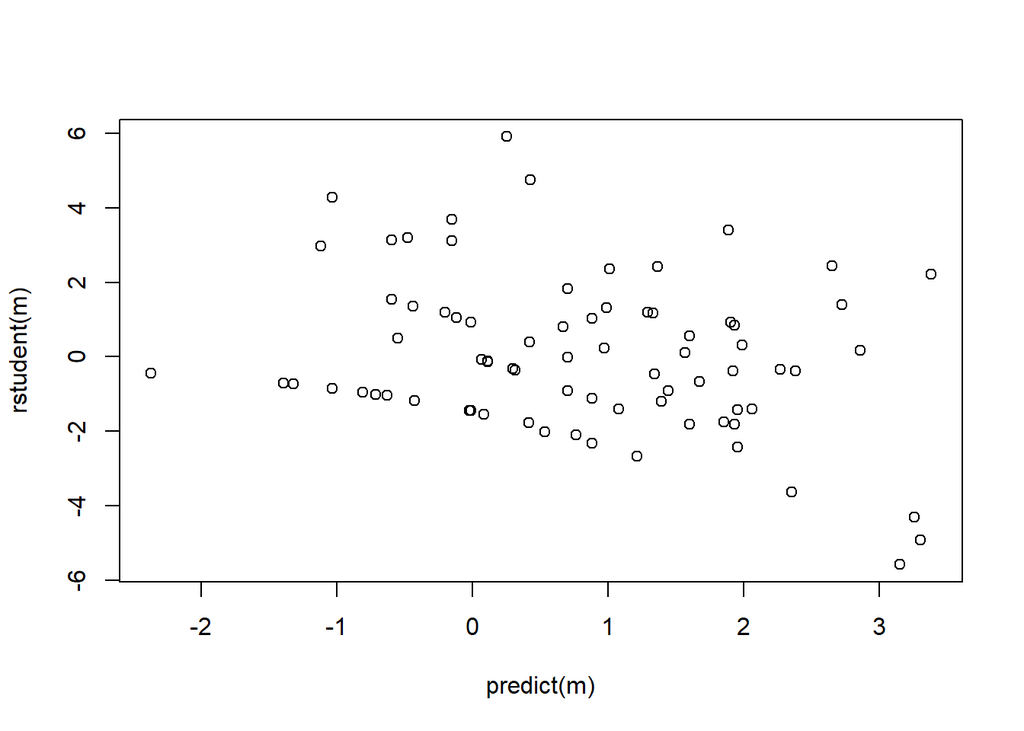

```r
plot(predict(m), rstudent(m))
```

#### 6. Using data from the df moths, estimate a logistic regression model for the proportion of moths in each transect that are of type P, but using only habitat type as your explanatory variables, Be sure to drop data from the “Bank” habitat type. Report parameter estimates, se’s, and CI’s.

```r
#remove 'Bank' habitat data
moths.subset <- subset(moths, habitat != "Bank")
head(moths.subset)
```

```
##   meters A  P   habitat
## 1     25 9  8    NWsoak
## 2     37 3 20    SWsoak
## 3    109 7  9 Lowerside
## 4     10 0  2 Lowerside
## 5    133 9  1 Upperside
## 6     26 3 18 Disturbed
```

```r
#logistic regression model
m <- glm(cbind(P, A) ~ habitat, family = binomial, data = moths.subset)
cbind(summary(m)$coefficients, confint(m))
```

```
##                  Estimate Std. Error z value  Pr(>|z|)   2.5 %  97.5 %
## (Intercept)        1.4171     0.3941   3.596 3.233e-04  0.6954  2.2619
## habitatLowerside  -2.2974     0.4884  -4.704 2.549e-06 -3.3099 -1.3808
## habitatNEsoak     -1.4171     0.5460  -2.595 9.455e-03 -2.5280 -0.3702
## habitatNWsoak     -2.7353     0.4712  -5.805 6.432e-09 -3.7170 -1.8549
## habitatSEsoak     -3.2362     0.5907  -5.478 4.292e-08 -4.4818 -2.1457
## habitatSWsoak     -0.5416     0.4755  -1.139 2.547e-01 -1.5201  0.3633
## habitatUpperside  -2.6698     0.5622  -4.749 2.041e-06 -3.8388 -1.6195
```

#### 7. For the Disturbed, Lowerside, and Upperside habitat types, use contrast to estimate: (a) the odds that a moth found a given habitat is P vs A, and (b) the probability that a moth found in a given habitat will be of type P, noting that the log of the odds produced by contrast can be converted to odds and probabilites by transforiming them with the R functions ‘exp’ and ‘plogis’ respectively.

```r
#a) odds
contrast(m,
         a = list(habitat = c('Disturbed', 'Lowerside', 'Upperside')),
         tf = exp, cnames = paste('P vs. A at', c('Disturbed', 'Lowerside', 'Upperside')))
```

```
##                      estimate     se  lower  upper tvalue  df    pvalue
## P vs. A at Disturbed   4.1250 0.3941 1.9054 8.9304  3.596 Inf 0.0003233
## P vs. A at Lowerside   0.4146 0.2885 0.2356 0.7298 -3.052 Inf 0.0022741
## P vs. A at Upperside   0.2857 0.4009 0.1302 0.6269 -3.125 Inf 0.0017784
```

```r
#b) probability
contrast(m,
         a = list(habitat = c('Disturbed', 'Lowerside', 'Upperside')),
         tf = plogis, cnames = paste('P vs. A at', c('Disturbed', 'Lowerside', 'Upperside')))
```

```
##                      estimate     se  lower  upper tvalue  df    pvalue
## P vs. A at Disturbed   0.8049 0.3941 0.6558 0.8993  3.596 Inf 0.0003233
## P vs. A at Lowerside   0.2931 0.2885 0.1907 0.4219 -3.052 Inf 0.0022741
## P vs. A at Upperside   0.2222 0.4009 0.1152 0.3853 -3.125 Inf 0.0017784
```